# IPI Workshop - Machine Learning Model Training and Selection

Carlos Calvo Hernandez

4/3/2019

## Model Selection

### Model Training and Parameter Tuning

The [`caret`](http://cran.r-project.org/web/packages/caret/index.html) package has several functions that attempt to streamline the model building and evaluation process.

The `train` function can be used to

- evaluate, using resampling, the effect of model tuning parameters on performance
- choose the “optimal” model across these parameters
- estimate model performance from a training set

First, a specific model must be chosen. Currently, 238 are available using [`caret`](http://cran.r-project.org/web/packages/caret/index.html); see [`train` Model List](https://topepo.github.io/caret/available-models.html) or [`train` Models By Tag](https://topepo.github.io/caret/train-models-by-tag.html) for details. On these pages, there are lists of tuning parameters that can potentially be optimized. [User-defined models](https://topepo.github.io/caret/using-your-own-model-in-train.html) can also be created.

The first step in tuning the model is to choose a set of parameters to evaluate. For example, if fitting a Partial Least Squares (PLS) model, the number of PLS components to evaluate must be specified.

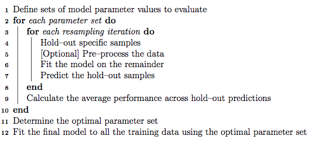

Once the model and tuning parameter values have been defined, the type of resampling should be also be specified. Currently, *k*-fold cross-validation (once or repeated), leave-one-out cross-validation and bootstrap (simple estimation or the 632 rule) resampling methods can be used by `train`. After resampling, the process produces a profile of performance measures is available to guide the user as to which tuning parameter values should be chosen. By default, the function automatically chooses the tuning parameters associated with the best value, although different algorithms can be used (see details below).

We’ll use the same `predicted` imputed dataset from Dataport that we used last week. It’s subset to 1% of the total observations to make calculations easier on R.

```r
glimpse(predicted)
```

```
## Observations: 2,956
## Variables: 51
## $ dataid               <dbl> -0.5471441, -0.5471441, -0.5465912, -0.5465…
## $ localhour            <dttm> 2016-01-11 21:00:00, 2016-01-12 13:00:00, …
## $ use                  <dbl> 1.19760386, 0.04866084, 0.34098761, -0.2149…
## $ aquarium1            <dbl> -0.07940467, -0.07940467, -0.07940467, -0.0…
## $ bedroom1             <dbl> -0.2705851, -0.2705851, -0.2705851, -0.2705…
## $ bedroom2             <dbl> -0.31186045, -0.31186045, -0.31186045, -0.3…
## $ bedroom3             <dbl> -0.416594, -0.416594, -0.416594, -0.416594,…
## $ bedroom4             <dbl> -0.544967, -0.544967, -0.544967, -0.544967,…
## $ clotheswasher_dryg1  <dbl> -0.2033043, -0.2033043, -0.2033043, -0.2033…
## $ furnace1             <dbl> 0.12053428, -0.37282418, -0.36288325, -0.08…
## $ furnace2             <dbl> -0.2903093, -0.2903093, -0.2903093, -0.2903…
## $ garage1              <dbl> -0.2283121, -0.2283121, -0.2283121, -0.2283…
## $ garage2              <dbl> 0.02468839, 0.02468839, 0.02468839, 0.02468…
```

[output cut: 38 more lines]

The function `createDataPartition` can be used to create a stratified random sample of the data into training and test sets:

```r
library(caret)
set.seed(998)
inTraining <- createDataPartition(predicted$use, p = .75, list = FALSE)
training <- predicted[ inTraining,]
testing  <- predicted[-inTraining,]
```

We will use these data illustrate functionality on this (and other) pages.

### Basic Parameter Tuning

By default, simple bootstrap resampling is used for line 3 in the algorithm above. Others are available, such as repeated *K*-fold cross-validation, leave-one-out etc. The function `trainControl` can be used to specifiy the type of resampling:

```r
fitControl <- trainControl(# 5-fold CV
                           method = "repeatedcv",
                           number = 5,
                           # repeated five times
                           repeats = 5)
```

More information about `trainControl` is given in the [caret documentation](https://topepo.github.io/caret/model-training-and-tuning.html#custom).

The first two arguments to `train` are the predictor and outcome data objects, respectively. The third argument, `method`, specifies the type of model (see [`train` Model List](https://topepo.github.io/caret/available-models.html') or [`train` Models By Tag](https://topepo.github.io/caret/train-models-by-tag.html). To illustrate, we will fit a boosted tree model via the [`gbm`](http://cran.r-project.org/web/packages/gbm/index.html) package. The basic syntax for fitting this model using repeated cross-validation is shown below:

```r
set.seed(825)
gbmFit1 <- train(use ~ ., data = training,
                 method = "gbm",
                 trControl = fitControl,
                 ## This last option is actually one
                 ## for gbm() that passes through
                 verbose = FALSE)
gbmFit1
```

```
## Stochastic Gradient Boosting
##
## 2220 samples
##   50 predictor
##
## No pre-processing
## Resampling: Cross-Validated (5 fold, repeated 5 times)
## Summary of sample sizes: 1776, 1776, 1776, 1776, 1776, 1776, ...
## Resampling results across tuning parameters:
##
##   interaction.depth  n.trees  RMSE       Rsquared   MAE
##   1                   50      0.6163296  0.6601721  0.2803571
##   1                  100      0.5925390  0.6798515  0.2509406
##   1                  150      0.5873166  0.6857997  0.2441579
##   2                   50      0.5955527  0.6787771  0.2502450
##   2                  100      0.5879900  0.6825481  0.2407788
##   2                  150      0.5851570  0.6855775  0.2396712
##   3                   50      0.5911876  0.6808022  0.2412514
##   3                  100      0.5908676  0.6800476  0.2394693
##   3                  150      0.5888271  0.6827280  0.2380101
##
## Tuning parameter 'shrinkage' was held constant at a value of 0.1
##
## Tuning parameter 'n.minobsinnode' was held constant at a value of 10
## RMSE was used to select the optimal model using the smallest value.
## The final values used for the model were n.trees = 150,
##  interaction.depth = 2, shrinkage = 0.1 and n.minobsinnode = 10.
```

- number of iterations, i.e. trees, (called `n.trees` in the `gbm` function)
- complexity of the tree, called `interaction.depth`
- learning rate: how quickly the algorithm adapts, called `shrinkage`
- the minimum number of training set samples in a node to commence splitting (`n.minobsinnode`)

The default values tested for this model are shown in the first two columns (`shrinkage` and `n.minobsinnode` are not shown beause the grid set of candidate models all use a single value for these tuning parameters). `train` works with specific models.

For these models, `train` can automatically create a grid of tuning parameters. By default, if *p* is the number of tuning parameters, the grid size is *3^p*.

### Customizing the Tuning Process

There are a few ways to customize the process of selecting tuning/complexity parameters and building the final model.

#### Alternate Tuning Grids

For the boosted tree model, we can fix the learning rate and evaluate more than three values of `n.trees`:

```r
gbmGrid <-  expand.grid(interaction.depth = c(1, 5, 9),
                        n.trees = (1:5)*50,
                        shrinkage = 0.1,
                        n.minobsinnode = 20)

nrow(gbmGrid)
set.seed(825)
gbmFit2 <- train(use ~ ., data = training,
                 method = "gbm",
                 trControl = fitControl,
                 verbose = FALSE,
                 ## Now specify the exact models
                 ## to evaluate:
                 tuneGrid = gbmGrid)
gbmFit2
```

```
## Stochastic Gradient Boosting
##
## 2220 samples
##   50 predictor
##
## No pre-processing
## Resampling: Cross-Validated (5 fold, repeated 5 times)
## Summary of sample sizes: 1776, 1776, 1776, 1776, 1776, 1776, ...
## Resampling results across tuning parameters:
##
##   interaction.depth  n.trees  RMSE  Rsquared  MAE
##   1                   50      0.67  0.60      0.29
##   1                  100      0.65  0.62      0.28
##   1                  150      0.64  0.63      0.27
##   1                  200      0.64  0.63      0.27
##   1                  250      0.64  0.63      0.27
##   5                   50      0.63  0.63      0.25
##   5                  100      0.63  0.64      0.25
##   :                   :        :         :
##   9                  100      0.62  0.65      0.23
##   9                  150      0.62  0.65      0.23
##   9                  200      0.62  0.65      0.23
##   9                  250      0.62  0.65      0.23
##
## Tuning parameter 'shrinkage' was held constant at a value of 0.1
##
## Tuning parameter 'n.minobsinnode' was held constant at a value of 20
## RMSE was used to select the optimal model using the smallest value.
## The final values used for the model were n.trees = 150,
##  interaction.depth = 9, shrinkage = 0.1 and n.minobsinnode = 20.
```

Another option is to use a random sample of possible tuning parameter combinations, i.e. “random search”[(pdf)](http://www.jmlr.org/papers/volume13/bergstra12a/bergstra12a.pdf). This functionality is described on [this page](https://topepo.github.io/caret/random-hyperparameter-search.html).

To use a random search, use the option `search = "random"` in the call to `trainControl`. In this situation, the `tuneLength` parameter defines the total number of parameter combinations that will be evaluated.

#### Plotting the Resampling Profile

The `plot` function can be used to examine the relationship between the estimates of performance and the tuning parameters. For example, a simple invokation of the function shows the results for the first performance measure:

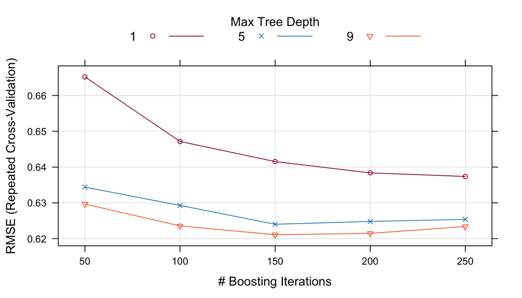

```r
trellis.par.set(caretTheme())
plot(gbmFit2)
```

Other performance metrics can be shown using the `metric` option:

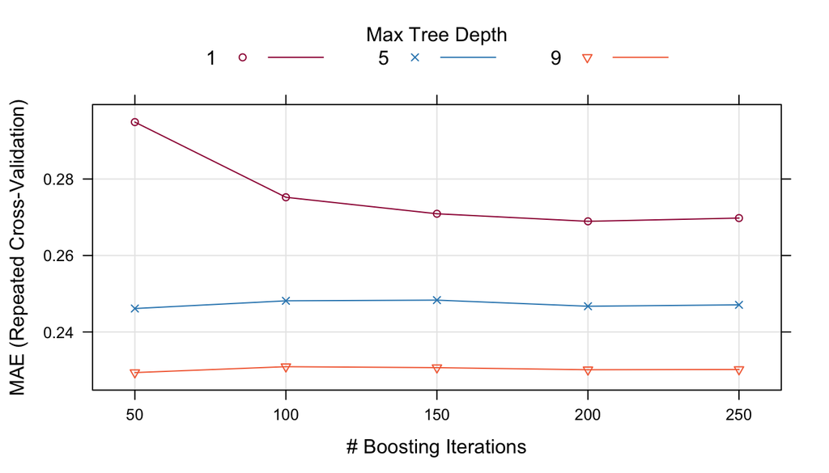

```r
trellis.par.set(caretTheme())
plot(gbmFit2, metric = "MAE")
```

Other types of plot are also available. See `?plot.train` for more details. The code below shows a heatmap of the results:

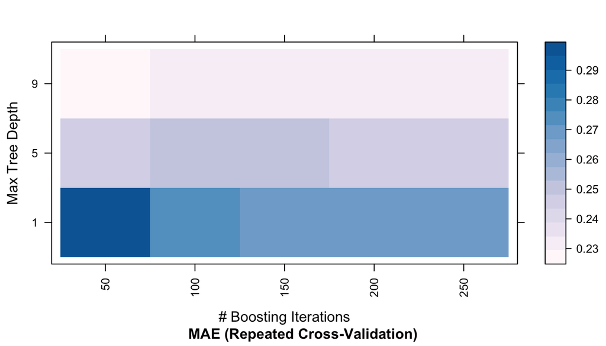

```r
trellis.par.set(caretTheme())
plot(gbmFit2, metric = "MAE", plotType = "level",
     scales = list(x = list(rot = 90)))
```

A `ggplot` method can also be used:

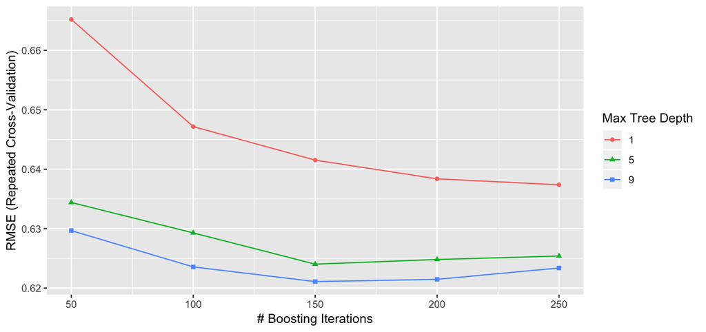

```r
ggplot(gbmFit2)
```

There are also plot functions that show more detailed representations of the resampled estimates. See `?xyplot.train` for more details.

From these plots, a different set of tuning parameters may be desired. To change the final values without starting the whole process again, the `update.train` can be used to refit the final model. See `?update.train`

#### Alternate Performance Metrics

The user can change the metric used to determine the best settings. By default, RMSE, *R*<sup>2</sup>, and the mean absolute error (MAE) are computed for regression while accuracy and Kappa are computed for classification. Also by default, the parameter values are chosen using RMSE and accuracy, respectively for regression and classification. The `metric` argument of the `train` function allows the user to control which the optimality criterion is used. For example, in problems where there are a low percentage of samples in one class, using `metric = "Kappa"` can improve quality of the final model.

If none of these parameters are satisfactory, the user can also compute custom performance metrics. The `trainControl` function has a argument called `summaryFunction` that specifies a function for computing performance. The function should have these arguments:

- `data` is a reference for a data frame or matrix with columns called `obs` and `pred` for the observed and predicted outcome values (either numeric data for regression or character values for classification). Currently, class probabilities are not passed to the function. The values in data are the held-out predictions (and their associated reference values) for a single combination of tuning parameters. If the `classProbs` argument of the `trainControl` object is set to `TRUE`, additional columns in `data` will be present that contains the class probabilities. The names of these columns are the same as the class levels. Also, if `weights` were specified in the call to `train`, a column called `weights` will also be in the data set. Additionally, if the `recipe` method for `train` was used (see this section of documentation), other variables not used in the model will also be included. This can be accomplished by adding a role in the recipe of `"performance var"`. An example is given in the recipe section of this site.
- `lev` is a character string that has the outcome factor levels taken from the training data. For regression, a value of `NULL` is passed into the function.
- `model` is a character string for the model being used (i.e. the value passed to the `method` argument of `train`).

The output to the function should be a vector of numeric summary metrics with non-null names. By default, `train` evaluate classification models in terms of the predicted classes. Optionally, class probabilities can also be used to measure performance. To obtain predicted class probabilities within the resampling process, the argument `classProbs` in `trainControl` must be set to `TRUE`. This merges columns of probabilities into the predictions generated from each resample (there is a column per class and the column names are the class names).

As shown in the last section, custom functions can be used to calculate performance scores that are averaged over the resamples. Another built-in function, `twoClassSummary`, will compute the sensitivity, specificity and area under the ROC curve:

```r
head(twoClassSummary)
```

```
##
## 1 function (data, lev = NULL, model = NULL)
## 2 {
## 3     lvls <- levels(data$obs)
## 4     if (length(lvls) > 2)
## 5         stop(paste("Your outcome has", length(lvls), "levels. The twoClassSummary() function isn't appropriate."))
## 6     requireNamespaceQuietStop("ModelMetrics")
```

```r
fitControl <- trainControl(method = "repeatedcv",
                           number = 5,
                           repeats = 5,
                           ## Estimate class probabilities
                           classProbs = TRUE,
                           ## Evaluate performance using
                           ## the following function
                           summaryFunction = twoClassSummary)
set.seed(825)
gbmFit3 <- train(use ~ ., data = training,
                 method = "gbm",
                 trControl = fitControl,
                 verbose = FALSE,
                 tuneGrid = gbmGrid,
                 ## Specify which metric to optimize
                 metric = "Rsquared")
gbmFit3
```

[output not shown]

## Choosing the Final Model

Another method for customizing the tuning process is to modify the algorithm that is used to select the “best” parameter values, given the performance numbers. By default, the `train` function chooses the model with the largest performance value (or smallest, for mean squared error in regression models). Other schemes for selecting model can be used.

`train` allows the user to specify alternate rules for selecting the final model. The argument `selectionFunction` can be used to supply a function to algorithmically determine the final model. There are three existing functions in the package: `best` chooses the largest/smallest value, `oneSE` attempts to capture the spirit of [Breiman et al (1984)](http://books.google.com/books/about/Classification_and_Regression_Trees.html?id=JwQx-WOmSyQC) “the ‘one standard error rule’”, and `tolerance` selects the least complex model within some percent tolerance of the best value. See `?best` for more details.

User-defined functions can be used, as long as they have the following arguments:

- `x` is a data frame containing the tune parameters and their associated performance metrics. Each row corresponds to a different tuning parameter combination.
- `metric` a character string indicating which performance metric should be optimized (this is passed in directly from the `metric` argument of `train`.
- `maximize` is a single logical value indicating whether larger values of the performance metric are better (this is also directly passed from the call to `train`).

The function should output a single integer indicating which row in `x` is chosen.

The main issue with these functions is related to ordering the models from simplest to complex. In some cases, this is easy (e.g. simple trees, partial least squares), but in cases such as this model, the ordering of models is subjective. For example, is a boosted tree model using 100 iterations and a tree depth of 2 more complex than one with 50 iterations and a depth of 8? The package makes some choices regarding the orderings. In the case of boosted trees, the package assumes that increasing the number of iterations adds complexity at a faster rate than increasing the tree depth, so models are ordered on the number of iterations then ordered with depth. See `?best` for more examples for specific models.

## Appendix: The `trainControl` Function Cheatsheet

The function `trainControl` generates parameters that further control how models are created, with possible values:

- `method`: The resampling method: `"boot"`, `"cv"`, `"LOOCV"`, `"LGOCV"`, `"repeatedcv"`, `"timeslice"`, `"none"` and `"oob"`. The last value, out-of-bag estimates, can only be used by random forest, bagged trees, bagged earth, bagged flexible discriminant analysis, or conditional tree forest models. GBM models are not included (the [`gbm`](http://cran.r-project.org/web/packages/gbm/index.html) package maintainer has indicated that it would not be a good idea to choose tuning parameter values based on the model OOB error estimates with boosted trees). Also, for leave-one-out cross-validation, no uncertainty estimates are given for the resampled performance measures.
- `number` and `repeats`: `number` controls with the number of folds in *K*-fold cross-validation or number of resampling iterations for bootstrapping and leave-group-out cross-validation. `repeats` applied only to repeated *K*-fold cross-validation. Suppose that `method = "repeatedcv"`, `number = 10` and `repeats = 3`,then three separate 10-fold cross-validations are used as the resampling scheme.
- `verboseIter`: A logical for printing a training log.
- `returnData`: A logical for saving the data into a slot called `trainingData`.
- `p`: For leave-group out cross-validation: the training percentage
- For `method = "timeslice"`, `trainControl` has options `initialWindow`, `horizon` and `fixedWindow` that govern how cross-validation can be used for time series data.
- `classProbs`: a logical value determining whether class probabilities should be computed for held-out samples during resample.
- `index` and `indexOut`: optional lists with elements for each resampling iteration. Each list element is the sample rows used for training at that iteration or should be held-out. When these values are not specified, `train` will generate them.
- `summaryFunction`: a function to computed alternate performance summaries.
- `selectionFunction`: a function to choose the optimal tuning parameters. and examples.
- `PCAthresh`, `ICAcomp` and `k`: these are all options to pass to the `preProcess` function (when used).
- `returnResamp`: a character string containing one of the following values: `"all"`, `"final"` or `"none"`. This specifies how much of the resampled performance measures to save.
- `allowParallel`: a logical that governs whether `train` should use parallel processing (if availible).

There are several other options not discussed here.

## Appendix: Model Comparison

In this final section, we are going to compare different predictive models and choose the best one using the tools presented in the previous sections.

For this section, we are going to use the `churn` data. Below, we see that about 15% of the customers churn. It is important to maintain this proportion in all of the folds.

```r
library("C50")
data(churn)
table(churnTrain$churn)/nrow(churnTrain)
```

```
##
##       yes        no
## 0.1449145 0.8550855
```

Previously, when creating a train control object, we specified the method as `"cv"` and the number of folds. Now, as we want the same folds to be re-used over multiple model training rounds, we are going to pass the train/test splits directly. These splits are created with the `createFolds` function, which creates a list (here of length 5) containing the element indices for each fold.

```r
myFolds <- createFolds(churnTrain$churn, k = 5)
str(myFolds)
```

```
## List of 5
##  $ Fold1: int [1:667] 4 9 10 12 24 37 39 42 44 45 ...
##  $ Fold2: int [1:666] 5 14 17 20 26 47 53 55 56 57 ...
##  $ Fold3: int [1:667] 3 7 8 13 15 16 21 27 28 31 ...
##  $ Fold4: int [1:666] 2 11 19 30 35 36 38 40 41 43 ...
##  $ Fold5: int [1:667] 1 6 18 22 23 25 29 34 46 49 ...
```

We can easily verify that the folds maintain the proportion of yes/no results.

```r
sapply(myFolds, function(i) {
    table(churnTrain$churn[i])/length(i)
})
```

```
##         Fold1     Fold2     Fold3     Fold4     Fold5
## yes 0.1454273 0.1441441 0.1454273 0.1441441 0.1454273
## no  0.8545727 0.8558559 0.8545727 0.8558559 0.8545727
```

We can now create a train control object to be reused consistently for different model trainings.

```r
myControl <- trainControl(
  summaryFunction = twoClassSummary,
  classProb = TRUE,
  verboseIter = FALSE,
  savePredictions = TRUE,
  index = myFolds
)
```

### `glmnet` model

The `glmnet` is a linear model with built-in variable selection and coefficient regularisation.

```r
glm_model <- train(churn ~ .,
                   churnTrain,
                   metric = "ROC",
                   method = "glmnet",
                   tuneGrid = expand.grid(
                       alpha = 0:1,
                       lambda = 0:10/10),
                   trControl = myControl)
print(glm_model)
```

```
## glmnet
##
## 3333 samples
##   19 predictor
##    2 classes: 'yes', 'no'
##
## No pre-processing
## Resampling: Bootstrapped (5 reps)
## Summary of sample sizes: 667, 666, 667, 666, 667
## Resampling results across tuning parameters:
##
##   alpha  lambda  ROC        Sens          Spec
##   0      0.0     0.7563566  0.2334444578  0.9572807
##   0      0.1     0.7723497  0.0745324068  0.9932456
##   0      0.2     0.7728157  0.0181132934  0.9992982
##   0      0.3     0.7722671  0.0041410612  0.9999123
##   0      0.4     0.7716333  0.0005181347  1.0000000
##   0      0.5     0.7710540  0.0005181347  1.0000000
##   0      0.6     0.7705650  0.0000000000  1.0000000
##   0      0.7     0.7701426  0.0000000000  1.0000000
##   0      0.8     0.7697786  0.0000000000  1.0000000
##   0      0.9     0.7694986  0.0000000000  1.0000000
##   0      1.0     0.7692191  0.0000000000  1.0000000
##   1      0.0     0.7191835  0.2707059753  0.9429825
##   1      0.1     0.5202458  0.0000000000  1.0000000
##   1      0.2     0.5000000  0.0000000000  1.0000000
##   1      0.3     0.5000000  0.0000000000  1.0000000
##   1      0.4     0.5000000  0.0000000000  1.0000000
##   1      0.5     0.5000000  0.0000000000  1.0000000
##   1      0.6     0.5000000  0.0000000000  1.0000000
##   1      0.7     0.5000000  0.0000000000  1.0000000
##   1      0.8     0.5000000  0.0000000000  1.0000000
##   1      0.9     0.5000000  0.0000000000  1.0000000
##   1      1.0     0.5000000  0.0000000000  1.0000000
##
## ROC was used to select the optimal model using the largest value.
## The final values used for the model were alpha = 0 and lambda = 0.2.
```

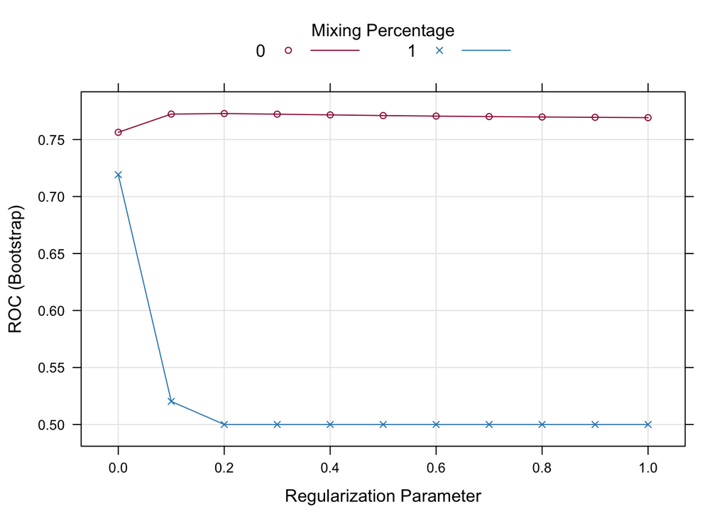

```r
plot(glm_model)
```

Below, we are going to repeat this same modelling with a variety of different classifiers, some of which we haven’t looked at. This illustrates another advantage of of using **meta-packages** such as `caret"`, that provide a consistant interface to different backends (in this case for machine learning). Once we have mastered the interface, it becomes easy to apply it to a new backend.

Note that some of the model training below will take some time to run, depending on the tuning parameter settings.

### random forest model

```r
rf_model <- train(churn ~ .,
                  churnTrain,
                  metric = "ROC",
                  method = "ranger",
                  # tuneGrid = expand.grid(
                  #     mtry = c(2, 5, 10, 19),
                  #     splitrule = c("gini", "extratrees")),
                  trControl = myControl)
print(rf_model)
```

```
## Random Forest
##
## 3333 samples
##   19 predictor
##    2 classes: 'yes', 'no'
##
## No pre-processing
## Resampling: Bootstrapped (5 reps)
## Summary of sample sizes: 667, 666, 667, 666, 667
## Resampling results across tuning parameters:
##
##   mtry  splitrule   ROC        Sens       Spec
##    2    gini        0.8666065  0.0430025  0.9995614
##    2    extratrees  0.8271683  0.0000000  1.0000000
##   35    gini        0.9059476  0.6775408  0.9822807
##   35    extratrees  0.9011359  0.5061734  0.9866667
##   69    gini        0.9046446  0.6697915  0.9794737
##   69    extratrees  0.9028934  0.5838173  0.9828070
##
## Tuning parameter 'min.node.size' was held constant at a value of 1
## ROC was used to select the optimal model using the largest value.
## The final values used for the model were mtry = 35, splitrule = gini
##  and min.node.size = 1.
```

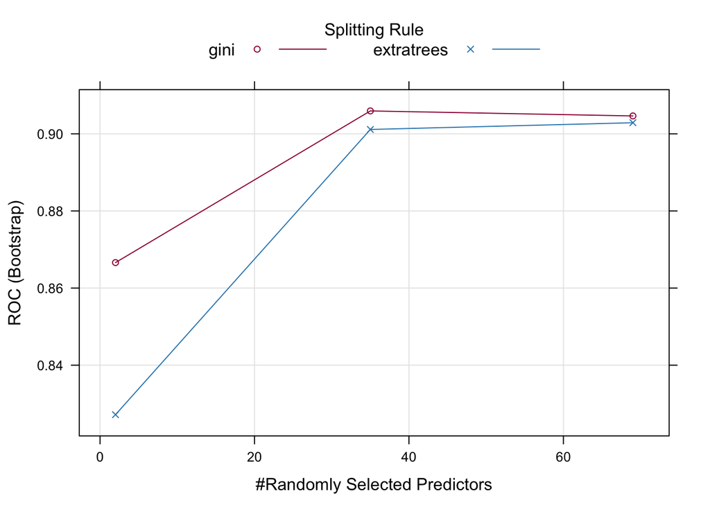

```r
plot(rf_model)
```

### kNN model

```r
knn_model <- train(churn ~ .,
                   churnTrain,
                   metric = "ROC",
                   method = "knn",
                   tuneLength = 20,
                   trControl = myControl)
print(knn_model)
```

```
## k-Nearest Neighbors
##
## 3333 samples
##   19 predictor
##    2 classes: 'yes', 'no'
##
## No pre-processing
## Resampling: Bootstrapped (5 reps)
## Summary of sample sizes: 667, 666, 667, 666, 667
## Resampling results across tuning parameters:
##
##   k   ROC        Sens        Spec
##    5  0.6707235  0.21377007  0.9797368
##    7  0.6809117  0.20237780  0.9884211
##    9  0.6872417  0.17909253  0.9915789
##   11  0.6950586  0.16305311  0.9932456
##   13  0.6990714  0.14959500  0.9940351
##   15  0.7014806  0.14027393  0.9950000
##   17  0.7061238  0.12733663  0.9956140
##   19  0.7079286  0.12009211  0.9955263
##   21  0.7098195  0.10870386  0.9963158
##   23  0.7109543  0.10042709  0.9970175
##   25  0.7117419  0.09576522  0.9971053
##   27  0.7125206  0.08437429  0.9974561
##   29  0.7123862  0.07764523  0.9975439
##   31  0.7122686  0.07298737  0.9980702
##   33  0.7105435  0.06626100  0.9984211
##   35  0.7129047  0.06211860  0.9985088
##   37  0.7145179  0.05487274  0.9988596
##   39  0.7141088  0.04555703  0.9992982
##   41  0.7124823  0.04090051  0.9992982
##   43  0.7131404  0.03727624  0.9993860
##
## ROC was used to select the optimal model using the largest value.
## The final value used for the model was k = 37.
```

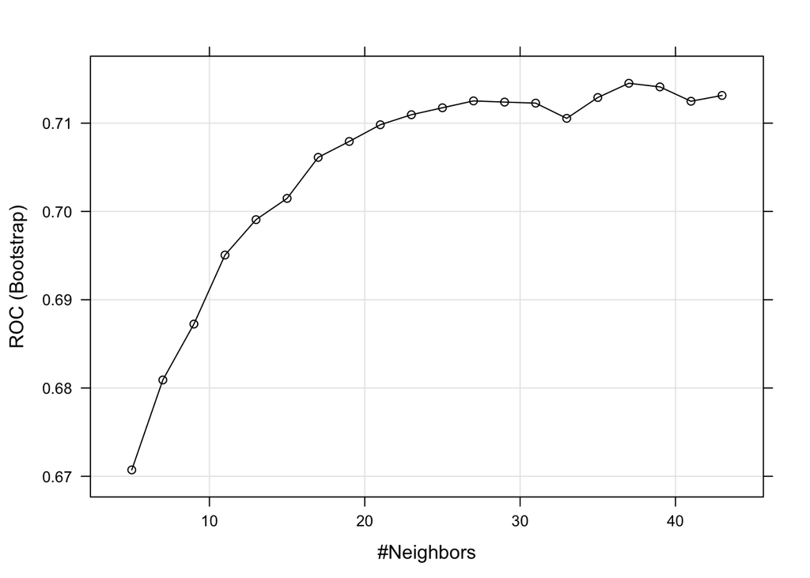

```r
plot(knn_model)
```

### Support vector machine model

```r
svm_model <- train(churn ~ .,
                   churnTrain,
                   metric = "ROC",
                   method = "svmRadial",
                   tuneLength = 10,
                   trControl = myControl)
print(svm_model)
```

```
## Support Vector Machines with Radial Basis Function Kernel
##
## 3333 samples
##   19 predictor
##    2 classes: 'yes', 'no'
##
## No pre-processing
## Resampling: Bootstrapped (5 reps)
## Summary of sample sizes: 667, 667, 666, 666, 667
## Resampling results across tuning parameters:
##
##   C       ROC        Sens       Spec
##     0.25  0.7996612  0.1832483  0.9768421
##     0.50  0.7996505  0.1289767  0.9836842
##     1.00  0.7996423  0.1573871  0.9808772
##     2.00  0.8005436  0.1444846  0.9840351
##     4.00  0.8073452  0.1708492  0.9855263
##     8.00  0.8085511  0.1759743  0.9864035
##    16.00  0.8019711  0.1847545  0.9823684
##    32.00  0.7929538  0.1956809  0.9800000
##    64.00  0.7879453  0.1770307  0.9824561
##   128.00  0.7873498  0.1760132  0.9830702
##
## Tuning parameter 'sigma' was held constant at a value of 0.00748696
## ROC was used to select the optimal model using the largest value.
## The final values used for the model were sigma = 0.00748696 and C = 8.
```

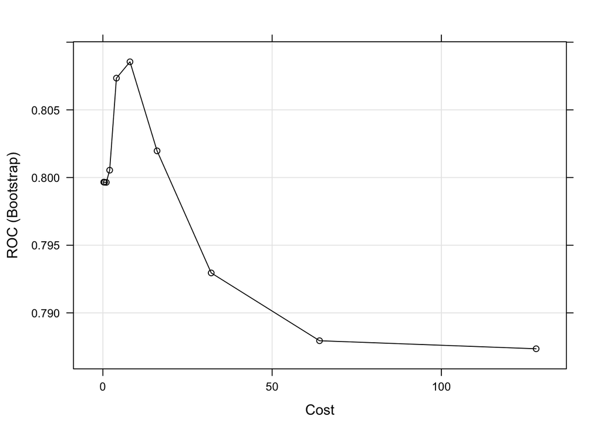

```r
plot(svm_model)
```

### Naive Bayes

```r
nb_model <- train(churn ~ .,
                  churnTrain,
                  metric = "ROC",
                  method = "naive_bayes",
                  trControl = myControl)
print(nb_model)
```

```
## Naive Bayes
##
## 3333 samples
##   19 predictor
##    2 classes: 'yes', 'no'
##
## No pre-processing
## Resampling: Bootstrapped (5 reps)
## Summary of sample sizes: 667, 666, 667, 666, 667
## Resampling results across tuning parameters:
##
##   usekernel  ROC        Sens      Spec
##   FALSE      0.5639545  0.989648  0.03201754
##    TRUE      0.8053416  0.000000  1.00000000
##
## Tuning parameter 'laplace' was held constant at a value of 0
##
## Tuning parameter 'adjust' was held constant at a value of 1
## ROC was used to select the optimal model using the largest value.
## The final values used for the model were laplace = 0, usekernel = TRUE
##  and adjust = 1.
```

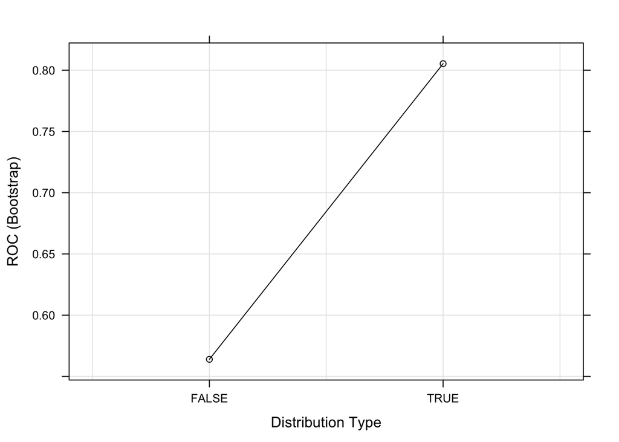

```r
plot(nb_model)
```

### Comparing models

We can now use the `caret::resamples` function that will compare the models and pick the one with the highest AUC and lowest AUC standard deviation.

```r
model_list <- list(glmmet = glm_model,
                   rf = rf_model,
                   knn = knn_model,
                   svm = svm_model,
                   nb = nb_model)
resamp <- resamples(model_list)
resamp
```

```
##
## Call:
## resamples.default(x = model_list)
##
## Models: glmmet, rf, knn, svm, nb
## Number of resamples: 5
## Performance metrics: ROC, Sens, Spec
## Time estimates for: everything, final model fit
```

```r
summary(resamp)
```

```
##
## Call:
## summary.resamples(object = resamp)
##
## Models: glmmet, rf, knn, svm, nb
## Number of resamples: 5
##
## ROC
##             Min.   1st Qu.    Median      Mean   3rd Qu.      Max. NA's
## glmmet 0.7583947 0.7685926 0.7767748 0.7728157 0.7779104 0.7824061    0
## rf     0.8992290 0.9010130 0.9053459 0.9059476 0.9088662 0.9152840    0
## knn    0.6960504 0.6979508 0.7204788 0.7145179 0.7262297 0.7318798    0
## svm    0.7870705 0.8069960 0.8099993 0.8085511 0.8114694 0.8272202    0
## nb     0.7865796 0.7926064 0.8011515 0.8053416 0.8137760 0.8325944    0
##
## Sens
##               Min.    1st Qu.     Median       Mean    3rd Qu.       Max.
## glmmet 0.007772021 0.01813472 0.02067183 0.01811329 0.02067183 0.02331606
## rf     0.635658915 0.64766839 0.65803109 0.67754080 0.71059432 0.73575130
## knn    0.038759690 0.03886010 0.05440415 0.05487274 0.05684755 0.08549223
## svm    0.108808290 0.16279070 0.18393782 0.17597435 0.20671835 0.21761658
## nb     0.000000000 0.00000000 0.00000000 0.00000000 0.00000000 0.00000000
##        NA's
## glmmet    0
## rf        0
## knn       0
## svm       0
## nb        0
##
## Spec
##             Min.   1st Qu.    Median      Mean   3rd Qu.      Max. NA's
## glmmet 0.9986842 0.9986842 0.9991228 0.9992982 1.0000000 1.0000000    0
## rf     0.9666667 0.9828947 0.9859649 0.9822807 0.9877193 0.9881579    0
## knn    0.9978070 0.9982456 0.9986842 0.9988596 0.9995614 1.0000000    0
## svm    0.9815789 0.9846491 0.9855263 0.9864035 0.9859649 0.9942982    0
## nb     1.0000000 1.0000000 1.0000000 1.0000000 1.0000000 1.0000000    0
```

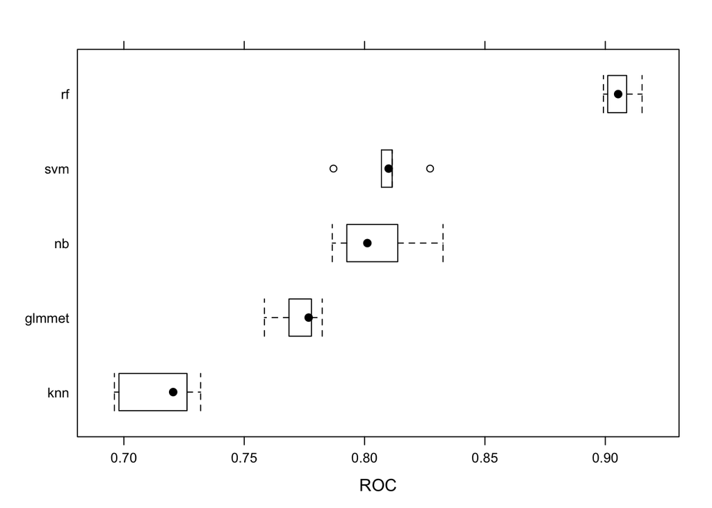

Comparing distributions of AUC values for various models.

```r
lattice::bwplot(resamp, metric = "ROC")
```

### Pre-processing

The random forest appears to be the best one. This might be related to its ability to cope well with different types of input and require little pre-processing.

```r
svm_model1 <- train(churn ~ .,
                    churnTrain,
                    metric = "ROC",
                    method = "svmRadial",
                    tuneLength = 10,
                    trControl = myControl)
svm_model2 <- train(churn ~ .,
                    churnTrain[, c(2, 6:20)],
                    metric = "ROC",
                    method = "svmRadial",
                    preProcess = c("scale", "center", "pca"),
                    tuneLength = 10,
                    trControl = myControl)
model_list <- list(svm1 = svm_model1,
                   svm2 = svm_model2)
resamp <- resamples(model_list)
summary(resamp)
```

```
##
## Call:
## summary.resamples(object = resamp)
##
## Models: svm1, svm2
## Number of resamples: 5
##
## ROC
##           Min.   1st Qu.    Median      Mean   3rd Qu.      Max. NA's
## svm1 0.7871341 0.8071141 0.8100583 0.8086648 0.8116274 0.8273902    0
## svm2 0.8069380 0.8124841 0.8277248 0.8218703 0.8284748 0.8337300    0
##
## Sens
##           Min.   1st Qu.    Median      Mean   3rd Qu.      Max. NA's
## svm1 0.1447028 0.1472868 0.1502591 0.1858591 0.2409326 0.2461140    0
## svm2 0.3704663 0.3937824 0.4031008 0.4109638 0.4366925 0.4507772    0
##
## Spec
##           Min.   1st Qu.    Median      Mean   3rd Qu.      Max. NA's
## svm1 0.9785088 0.9811404 0.9868421 0.9850000 0.9890351 0.9894737    0
## svm2 0.9750000 0.9789474 0.9802632 0.9796491 0.9802632 0.9837719    0
```

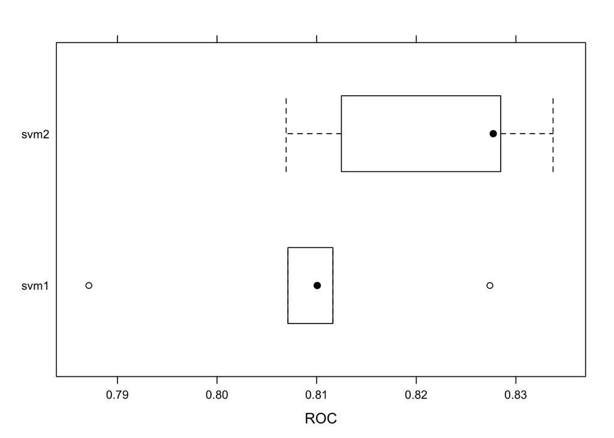

```r
bwplot(resamp, metric = "ROC")
```

### Predict using the best model

Now, choose the best model using the `resamples` function and compare the results and apply it to predict the `churnTest` labels.

```r
p <- predict(rf_model, churnTest)
confusionMatrix(p, churnTest$churn)
```

```
## Confusion Matrix and Statistics
##
##           Reference
## Prediction  yes   no
##        yes  164    6
##        no    60 1437
##
##                Accuracy : 0.9604
##                  95% CI : (0.9499, 0.9692)
##     No Information Rate : 0.8656
##     P-Value [Acc > NIR] : < 2.2e-16
##
##                   Kappa : 0.8105
##  Mcnemar's Test P-Value : 6.853e-11
##
##             Sensitivity : 0.73214
##             Specificity : 0.99584
##          Pos Pred Value : 0.96471
##          Neg Pred Value : 0.95992
##              Prevalence : 0.13437
##          Detection Rate : 0.09838
##    Detection Prevalence : 0.10198
##       Balanced Accuracy : 0.86399
##
##        'Positive' Class : yes
##
```

[^1]: Gradient boosting is a machine learning technique for regression and classification problems, which produces a prediction model in the form of an ensemble of weak prediction models, typically decision trees. It builds the model in a stage-wise fashion like other boosting methods do, and it generalizes them by allowing optimization of an arbitrary differentiable loss function.